Peppi-Lotta Saari  
Student number 517334  
February, 8, 2023

# Exercise 2 | TKO_7092 Evaluation of Machine Learning Methods 2023

### Prediction of the metal ion content from multi-parameter data

##### Use K-Nearest Neighbor Regression with euclidean distance to predict total metal concentration (c_total), concentration of Cadmium (Cd) and concentration of Lead (Pb), for each sample using number of neighbors k = 3.

```
- You may use Nearest Neighbor Regression from https://scikit-learn.org/stable/modules/neighbors.html
- The data should be standarized using z-score. (Using sklearn.preprocessing.StandardScaler is allowed)
- Implement your own Leave-One-Out cross-validation and calculate the C-index for each output (c_total, Cd, Pb).
- Implement your own Leave-Replicas-Out cross-validation and calculate the C-index for each output (c_total, Cd, Pb).
- Return your solution as a Jupyter Notebook .ipynb notebook and as a PDF-file made from it.
- Submit to moodle your solution on ** Wednesday 8 of February ** at the latest.
```

## Import libraries

```python
#In this cell import all libraries you need. For example:
import numpy as np
import pandas as pd
from matplotlib import pyplot as plt
from sklearn.preprocessing import StandardScaler
from sklearn.neighbors import KNeighborsRegressor
```

## Read and visualize the dataset

```python
#In this cell read the file Water_data.csv
#Print the dataset dimesions (i.e. number of rows and columns)
#Print the first 5 rows of the dataset

df = pd.read_csv('Water_data.csv')
print(df.shape)
df.head()
```

```
(225, 6)
```

|  | c_total | Cd | Pb | Mod1 | Mod2 | Mod3 |
| --- | --- | --- | --- | --- | --- | --- |
| 0 | 0 | 0.0 | 0.0 | 9945 | 119 | 72335 |
| 1 | 0 | 0.0 | 0.0 | 10786 | 117 | 82977 |
| 2 | 0 | 0.0 | 0.0 | 10812 | 120 | 98594 |
| 3 | 14 | 0.0 | 14.0 | 9742 | 127 | 154323 |
| 4 | 14 | 0.0 | 14.0 | 8495 | 120 | 131672 |

#### To show understanding of the data, answer the following questions:

- How many different mixtures of Cadmium (Cd) and Lead (Pb) were measured?
- How many total concentrations (c_total) were measured?
- How many mixtures have less than 4 replicas?
- Make plots of Lead (Pb) and Cadmium (Cd) mixtures for low and high concentrations.

Where low concentrations are those with c_total <= 100, while in high concentration c_total > 100.  
Hint: plots are similar to the ones presented in the video lecture.

```python
# How many different mixtures of Cadmium (Cd) and Lead (Pb) were measured?
mixtures = df.groupby(['Cd','Pb']).size().reset_index().rename(columns={0:'count'})
print(mixtures.shape[0])
```

```
67
```

```python
# How many total concentrations (c_total) were measured?
unique = df['c_total'].unique()
print(len(unique))
```

```
12
```

```python
# How many mixtures have less than 4 replicas?
mixtures_less_than_4 = mixtures.loc[mixtures['count'] < 4]
print(mixtures_less_than_4.shape[0])
```

```
43
```

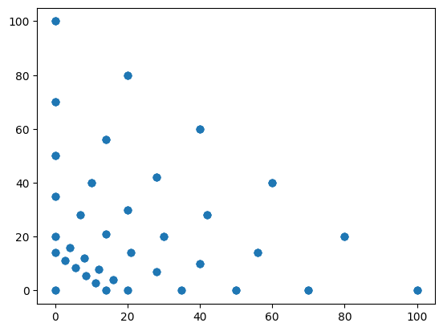

```python
# Make plots of Lead (Pb) and Cadmium (Cd) mixtures for low and high concentrations.
# Where low concentrations are those with c_total <= 100, while in high concentration c_total > 100.
# Hint: plots are similar to the ones presented in the video lecture.

df_low = df.loc[df['c_total'] <= 100]
plt.scatter(df_low['Cd'], df_low['Pb'])
```

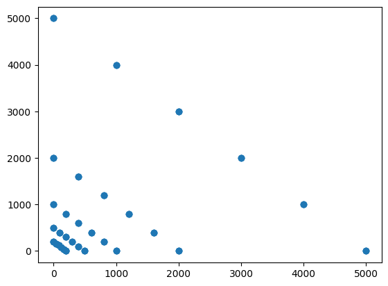

```python
df_high = df.loc[df['c_total'] > 100]
plt.scatter(df_high['Cd'], df_high['Pb'])
```

## Standardization of the dataset

```python
#In this cell standardize the dataset features by removing the mean and scaling to unit variance.
#In other words, use z-score to scale the dataset features (Mod1, Mod2, Mod3)
#Print the 5 first samples (i.e. rows) of the scaled dataset

# choose the columns to standardize
cols = ['Mod1', 'Mod2', 'Mod3']
features = df[cols]

#scale
scaler = StandardScaler()
scale = scaler.fit_transform(features)

#back to dataframe
features = pd.DataFrame(scale)
features.columns = cols
display(features.head())

#labels as it own dataframe
labels = df[['c_total', 'Cd', 'Pb']]
display(labels.head())

#whole dataframe with standardized features
df_st = df.copy()
df_st[cols] = features
display(df_st.head())
```

|  | Mod1 | Mod2 | Mod3 |
| --- | --- | --- | --- |
| 0 | -0.999216 | -0.714208 | -0.414911 |
| 1 | -0.990800 | -0.714373 | -0.238335 |
| 2 | -0.990539 | -0.714125 | 0.020788 |
| 3 | -1.001247 | -0.713546 | 0.945465 |
| 4 | -1.013727 | -0.714125 | 0.569631 |

|  | c_total | Cd | Pb |
| --- | --- | --- | --- |
| 0 | 0 | 0.0 | 0.0 |
| 1 | 0 | 0.0 | 0.0 |
| 2 | 0 | 0.0 | 0.0 |
| 3 | 14 | 0.0 | 14.0 |
| 4 | 14 | 0.0 | 14.0 |

|  | c_total | Cd | Pb | Mod1 | Mod2 | Mod3 |
| --- | --- | --- | --- | --- | --- | --- |
| 0 | 0 | 0.0 | 0.0 | -0.999216 | -0.714208 | -0.414911 |
| 1 | 0 | 0.0 | 0.0 | -0.990800 | -0.714373 | -0.238335 |
| 2 | 0 | 0.0 | 0.0 | -0.990539 | -0.714125 | 0.020788 |
| 3 | 14 | 0.0 | 14.0 | -1.001247 | -0.713546 | 0.945465 |
| 4 | 14 | 0.0 | 14.0 | -1.013727 | -0.714125 | 0.569631 |

## C-index code

```python
# taken from last week's assignment
def cindex(true_labels, pred_labels):
    n = 0
    h_num = 0
    for i in range(0, len(true_labels)):
        t = true_labels[i]
        p = pred_labels[i]
        for j in range(i+1, len(true_labels)):
            nt = true_labels[j]
            np = pred_labels[j]
            if (t != nt):
                n = n + 1
                if (p < np and t < nt) or (p > np and t > nt):
                    h_num += 1
                elif (p == np):
                    h_num += 0.5
    cindx =  h_num/n
    return cindx
```

```python
#test cindex function with following values
true_labels = [-1, 1, 1, -1, 1]
predictions = [0.60, 0.80, 0.75, 0.75, 0.70]
cindx = cindex(true_labels, predictions)
print(cindx)
```

```
0.75
```

```python
#test cindex function with following values
true_labels = [5,5,5]
predictions = [7,6,7]
cindx = cindex(true_labels, predictions)
print(cindx)
```

[output not shown]

## Functions

Include here all the functions that you need to run in the data analysis part.  
**Note:** using a leave-one-out and leave-replicas-out cross-validation from an already made package (e.g. Scikit-learn) is not accepted.

```python
### LEAVE-ONE-OUT

# make test/train splits for leave-one-out
def loo_split(feature_df, label_df, row):

        #separate a row from features to use as test set
        test_features = feature_df.iloc[[ row]]

        #drop the testing row from the training set
        train_features = feature_df.drop([row], axis=0)

        #separate a row from labels to use as test labels
        test_labels = label_df.iloc[[ row]]

        #drop the testing row from the training labels set
        train_labels = label_df.drop([row], axis=0)

        return test_features, train_features, test_labels, train_labels

# calculate c_index for predictions
def loo_cind():
    predictions = []
    #loop df_st rows
    for c in range(0, df_st.shape[0]):

        #make split
        test_features, train_features, test_labels, train_labels = loo_split(features, labels, c)

        # k-nn with 3 neigbours
        model = KNeighborsRegressor(n_neighbors=3)

        # Train the model using the training sets
        model.fit(train_features, train_labels)

        #Predict Output
        predicted = model.predict(test_features)

        predictions.append(predicted[0])

    # make prediction into a dataframe
    predictions = pd.DataFrame(predictions)
    predictions.columns = labels.columns

    c_index_total = cindex(labels['c_total'], predictions['c_total'])
    c_index_cd = cindex(labels['Cd'], predictions['Cd'])
    c_index_pb = cindex(labels['Pb'], predictions['Pb'])

    return c_index_total, c_index_cd, c_index_pb
```

```python
### LEAVE-REPLICAS-OUT FIXED

# make test/train splits for leave-replicas-out
def lro_split(m):

    # get indexis of replicas
    mixture = mixtures.iloc[[m]]
    m_cd = float(mixture['Cd'])
    m_pb = float(mixture['Pb'])
    replica_inds = labels[(labels['Cd'] == m_cd) & (labels['Pb'] == m_pb)].index

    # test sets
    test_features = features.iloc[replica_inds]
    test_labels = labels.iloc[replica_inds]

    #train sets
    train_features = features.drop(index=replica_inds)
    train_labels = labels.drop(index=replica_inds)

    return  test_features, train_features, test_labels, train_labels

def lro_cinds():
    #initialize dataframe to stode predicted values
    predicted_c_total = []
    c_total_labels = []

    predicted_cd = []
    cd_labels = []

    predicted_pb = []
    pb_labels = []

    # split dataset to leave replicas out
    # loop trough mixtures (mixtures are our replicas)
    for m in range(mixtures.shape[0]):

        #make split
        test_features, train_features, test_labels, train_labels = lro_split(m)

        # k-nn with 3 neigbours
        model = KNeighborsRegressor(n_neighbors=3)

        # Train the model using the training sets
        model.fit(train_features, train_labels)

        #Predict Output
        predicted = pd.DataFrame(model.predict(test_features))

        for index, row in predicted.iterrows():
            predicted_c_total.append(row[0])
            predicted_cd.append(row[1])
            predicted_pb.append(row[2])

        for index, row in test_labels.iterrows():
            c_total_labels.append(row['c_total'])
            cd_labels.append(row['Cd'])
            pb_labels.append(row['Pb'])

    # #c_index for each row
    c_index_total = cindex(c_total_labels, predicted_c_total)
    c_index_cd = cindex(cd_labels, predicted_cd)
    c_index_pb = cindex(pb_labels, predicted_pb)

    #print(c_index_total, c_index_cd, c_index_pb)
    return c_index_total, c_index_cd, c_index_pb
```

## Fixes i made

I simplified lro_split. I always use the same dataframes in this project so the method only takes the mixture dataframes index and forms the test/train splits based on that. Originally the method needed the feature and label dataframes as parameters. I also removed extra steps and the code is easier to red now.

The main difference in lro_cinds method is that instead of trying to use dataframes I use arrays to store the data and I form the predction arrays (one for each label) and actual labels arrays at the same time so I don't need to sort anything ot keep track of original indeces.

## Results for Leave-One-Out cross-validation

```python
#In this cell run your script for Leave-One-Out cross-validation and print the corresponding results.

c_index_total, c_index_cd, c_index_pb = loo_cind()

print('c_total c-index is ', c_index_total)
print('Cd c-index is ', c_index_cd)
print('Pb c-index is ', c_index_pb)
```

```
c_total c-index is  0.9141907740422205
Cd c-index is  0.8995907629348144
Pb c-index is  0.8744519146448407
```

## Results for Leave-Replicas-Out cross-validation

```python
#In this cell run your script for Leave-Replicas-Out cross-validation and print the corresponding results.

c_index_total, c_index_cd, c_index_pb = lro_cinds()

print('c_total c-index is ', c_index_total)
print('Cd c-index is ', c_index_cd)
print('Pb c-index is ', c_index_pb)
```

```
c_total c-index is  0.8186734427938493
Cd c-index is  0.7614523739925669
Pb c-index is  0.7689480937069362
```

## Interpretation of results

#### Answer the following questions based on the results obtained

- Which cross-validation approach had more optimistic results?
- Which cross-validation generalize better on unseen data? Why?

#### Which cross-validation approach had more optimistic results?

Leave-one-out. This cross-validation does well because we have the replicas in the training data. We assume datapoints to be independent when they are not. We end up always training the model with replicas when we only leave one sample out. This means the model has always seen the data we use for testing.

#### Which cross-validation generalize better on unseen data? Why?

Leave-Replicas_out. In this cross-validation system we take into account how some samples (the replicas) are dependent to eachother when we train the models. This way the model has never seen the data we test with un like in the leave-one-out. This is why this model will better generalize to unseen data.